# Ford GoBike System Data

### by Joel Minier-Matar

## Investigation Overview

> For this study we will be looking at the Ford GoBike system data for a full year from the beginning of April 2019 to the end of March 2020, over 2 million records will be analyzed to identify trends and patterns on the system users.

## Dataset Overview

> The ford wheels dataset contains information about bicycle rides for subscribers and customer. The set has the duration for each ride as well as the starting and ending stations.

## Type of users

> From the bike system users, over the year in consideration, 73% of the users are subscribers while 27% are customer

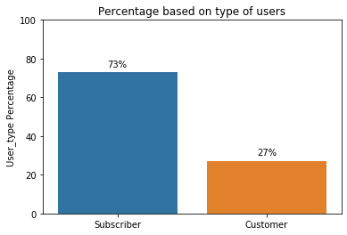

```python
typepercent=df.user_type.value_counts(normalize=True).apply(lambda x: x*100) #Normalizinmg the counts and transforming to percentage
fig, ax = plt.subplots(1,1)
sns.barplot(x=typepercent.index,y=typepercent)
plt.ylim(0,100)
plt.ylabel('User_type Percentage')
plt.title("Percentage based on type of users")
rects=ax.patches
for rect in rects:
    h = rect.get_height()
    ax.text(rect.get_x()+rect.get_width()/2., h+2,'{:0.0f}%'.format(h), ha='center', va='bottom');
```

## Trip duration

> The histogram for the time duration of each ride shows that an average duration of around 700 seconds (11-12 min) and it shows an exponential decline towards higher values.

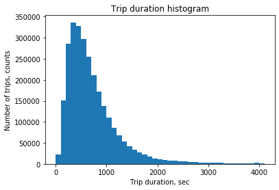

```python
bin_edges = np.arange(0, df['duration_sec'].max()+100, 100)
plt.hist(df['duration_sec'], bins = bin_edges)
plt.xlabel('Trip duration, sec')
plt.ylabel('Number of trips, counts')
plt.title('Trip duration histogram');
```

## Peak hours: Weekdays vs Weekend

> The histogram based on the hour of the day shows a bimodal distribution. The peak times for bike rides are in the morning between 7-10 am and in the evening between 4-7 pm.

> Weekdays trend are very similar to the overall trend; however, weekend trends are different. The weekend distribution is unimodal with peak rides in the early afternoon (2-3 pm). The data also showed less trips compared to weekdays.

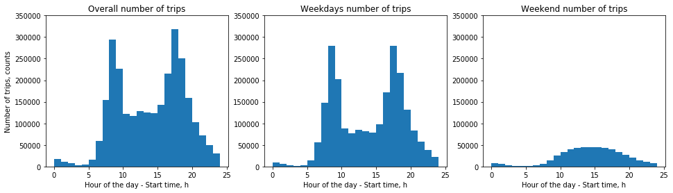

```python
plt.figure(figsize = [16,4])
base_color = sns.color_palette()[0]
bin_data=range(0,25,1)
plt.subplot(1, 3, 1)
plt.hist(df.start_time.dt.hour, bins=bin_data)
plt.xlabel('Hour of the day - Start time, h')
plt.title("Overall number of trips")
plt.ylabel('Number of trips, counts')
plt.ylim(0,350000);
plt.subplot(1, 3, 2)
plt.hist(df.query('weekday!="Sunday" and weekday!="Saturday"')['hour'], bins=bin_data)
plt.xlabel('Hour of the day - Start time, h')
plt.title("Weekdays number of trips")
plt.ylim(0,350000);
plt.subplot(1, 3, 3)
plt.hist(df.query('weekday=="Sunday" or weekday=="Saturday"')['hour'], bins=bin_data)
plt.xlabel('Hour of the day - Start time, h')
plt.title("Weekend number of trips")
plt.ylim(0,350000);
```

## Most popular stations

> Market St, Berry St and San Francisco Caltrain stations are the most popular stations to start a ride. Identifying the most popular stations could be helpful to know the main locations where bikes are needed.

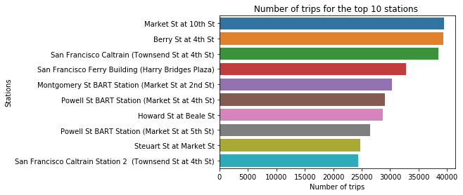

```python
sns.barplot(data=station_10_start,y='start_station_name',x='counts', order=station_10_start.start_station_name)
plt.xlabel('Number of trips')
plt.title("Number of trips for the top 10 stations ")
plt.ylabel('Stations');
```

## Market st. station: Distribution throughout the day

> The ride distribution over the day is similar between the bikes leaving the station (left plot) and the returning rides (right plot); which helps in balancing the number of bikes in the station.

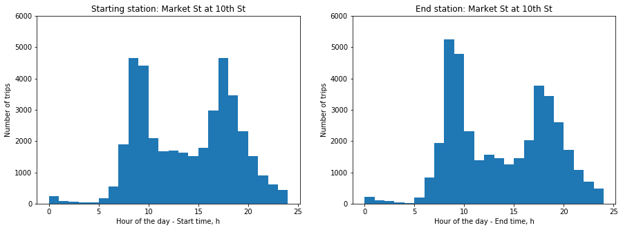

```python
plt.figure(figsize = [15, 5])
base_color = sns.color_palette()[0]
bin_data=range(0,25,1)
# left plot
plt.subplot(1, 2, 1)
plt.hist(df[df.start_station_name==station_10_start.start_station_name[0]]['start_time'].dt.hour, bins=bin_data);
plt.title('Starting station: ' + station_10_start.start_station_name[0])
plt.xlabel('Hour of the day - Start time, h')
plt.ylabel ('Number of trips')
plt.ylim(0,6000)
# right plot
plt.subplot(1, 2, 2)
plt.hist(df[df.end_station_name==station_10_end.end_station_name[4]]['end_time'].dt.hour, bins=bin_data)
plt.title('End station: '+station_10_end.end_station_name[4])
plt.xlabel('Hour of the day - End time, h')
plt.ylabel ('Number of trips')
plt.ylim(0,6000);
```

## San Francisco Caltrain station: Distribution throughout the day

> For this station, the ride distribution over the day showed that more bikes are usually returned to the station (right plot) compared to those leaving (left plot); which could translated to additional bikes in the station.

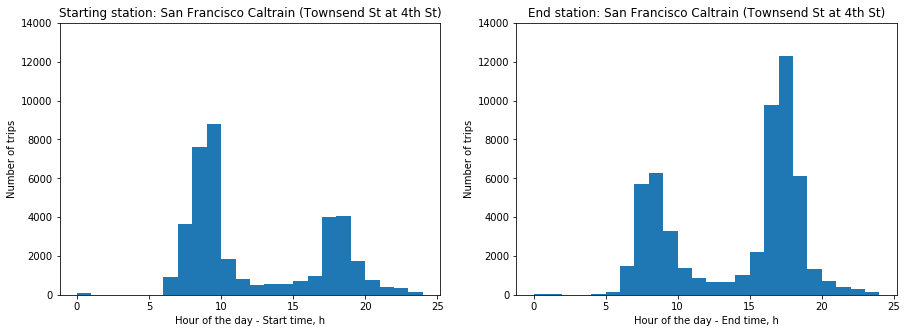

```python
plt.figure(figsize = [15, 5])
base_color = sns.color_palette()[0]
bin_data=range(0,25,1)
# left plot
plt.subplot(1, 2, 1)
plt.hist(df[df.start_station_name==station_10_start.start_station_name[2]]['start_time'].dt.hour, bins=bin_data);
plt.title('Starting station: ' + station_10_start.start_station_name[2])
plt.xlabel('Hour of the day - Start time, h')
plt.ylabel ('Number of trips')
plt.ylim(0,14000)
# right plot
plt.subplot(1, 2, 2)
plt.hist(df[df.end_station_name==station_10_end.end_station_name[0]]['end_time'].dt.hour, bins=bin_data)
plt.title('End station: '+station_10_end.end_station_name[0])
plt.xlabel('Hour of the day - End time, h')
plt.ylabel ('Number of trips')
plt.ylim(0,14000);
```

## Monthly Trends

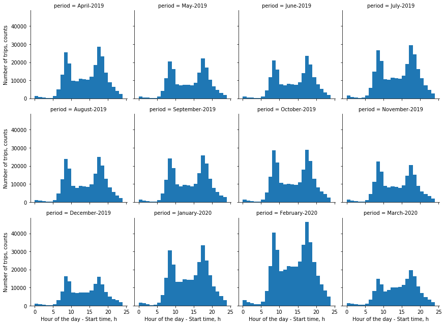

```python
bin_data=range(0,25,1)
g = sns.FacetGrid(data =df, col = 'period', col_wrap=4)
g.map(plt.hist,'hour',bins=bin_data)
g.axes[8].set_xlabel('Hour of the day - Start time, h')
g.axes[9].set_xlabel('Hour of the day - Start time, h')
g.axes[10].set_xlabel('Hour of the day - Start time, h')
g.axes[11].set_xlabel('Hour of the day - Start time, h')
g.axes[0].set_ylabel('Number of trips, counts')
g.axes[4].set_ylabel('Number of trips, counts')
g.axes[8].set_ylabel('Number of trips, counts');
```

## Group of users per day

> The data showed that subscribers are the main users of the system, specially during weekdays. On Weekend, the subscriber users are less compared to weekdays, but still higher than the customer users.

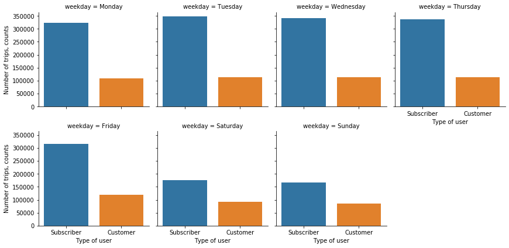

```python
g = sns.FacetGrid(data = df, col = 'weekday',col_wrap=4)
g.map(sns.countplot,'user_type', order=['Subscriber','Customer'],palette=sns.color_palette())
g.axes[3].set_xlabel('Type of user')
g.axes[4].set_xlabel('Type of user')
g.axes[5].set_xlabel('Type of user')
g.axes[6].set_xlabel('Type of user')
g.axes[0].set_ylabel('Number of trips, counts')
g.axes[4].set_ylabel('Number of trips, counts');
```